# Scenario: Zone Exclusion Management @ Nisqually

Describing the model run where managers attempt to exclude all pinnipeds from the Gauntlet via lethal removals at the Nisqually River

October 22, 2024

### The Narrative

This model run is a scenario where managers or harvesters (or both) attempt to remove all pinnipeds that enter the Gauntlet zone.

### Run the Model

Parameters listed below are altered from the base run parameterization to simulate the management scenario. For this scenario we’re enacting a zone exclusion management strategy.

```r
zone_efficiency <- 0.25
zone_steepness <- 10
scenario <- "Zone"
harvest_days_pv <- 1:days
harvest_days_ej <- 1:days
harvest_days_zc <- 1:days
```

### Description of Parameterization

This scenario is focused on the effects of implementing an Exclusion Zone management strategy in the Nisqually River. Under this strategy, both seals and sea lions are removed from the Gauntlet by managers throughout all days of the model run. The proportion of pinnipeds that are removed is governed by an efficiency term which describes the asymptote of the type II response between the number of pinnipeds at the Gauntlet and the number of individuals removed. That response is shown below:

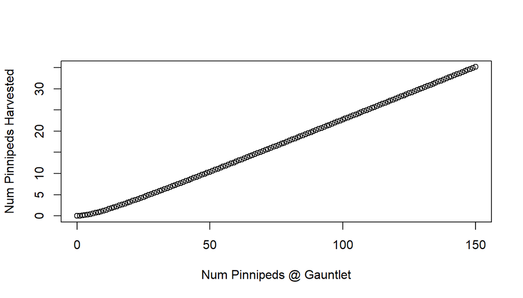

This management scenario is less feasible at Nisqually than at the Locks, so the efficiency parameter is much lower. The steepness parameter on the relationship between number of pinnipeds and efficiency of removals is also lower to represent the larger and more complex physical area for the pinnipeds to spread out in and be cryptic. In this parameterization, more pinnipeds would be removed from the system than under incidental take only. The below plots show how removals would be distributed through time during one model run.

Pinnipeds Removed

| Pv | Ej | Zc |
| --- | --- | --- |
| 27 | 2 | 72 |

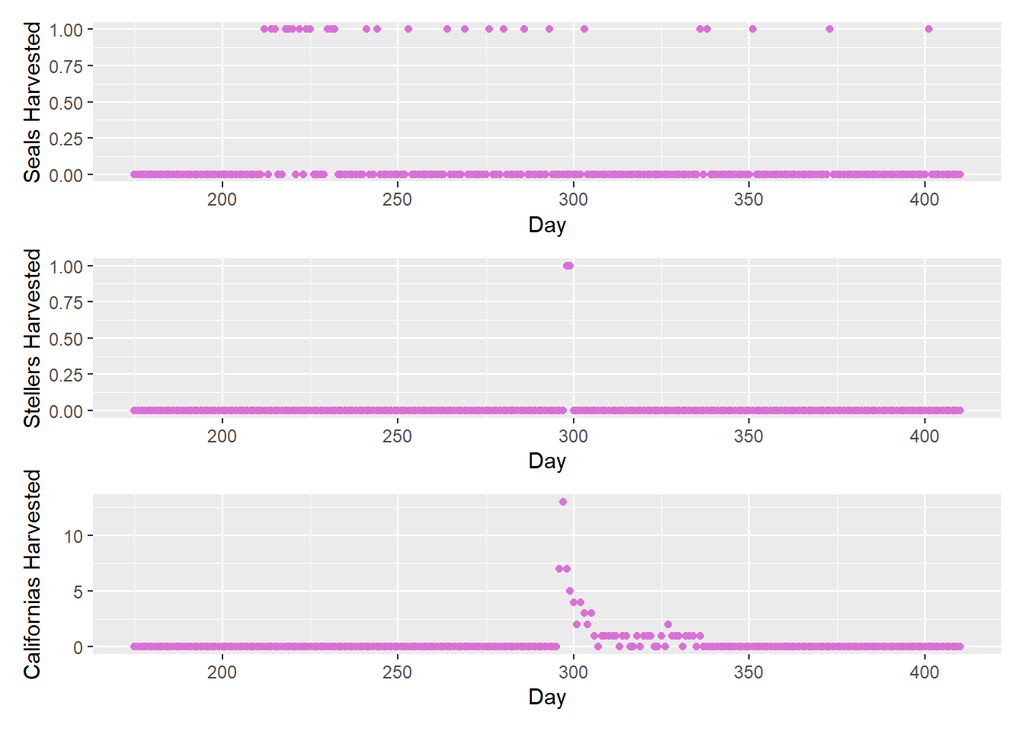

Because of the intensive removals, this scenario has an impact on pinniped behavior, presence at the Gauntlet, and survival.

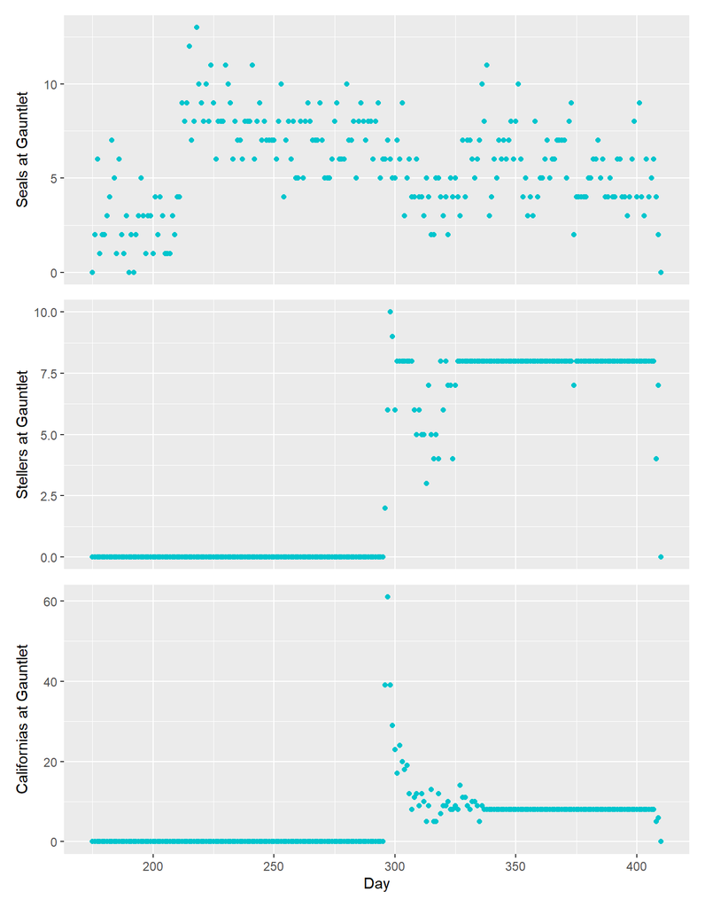

In the below plots, you can see how constant removals impact the learning process of individual harbor seals in the Gauntlet. A more negative y value indicates a higher degree of fear and a lower probability of chosing to go to the Gauntlet in the next time step.

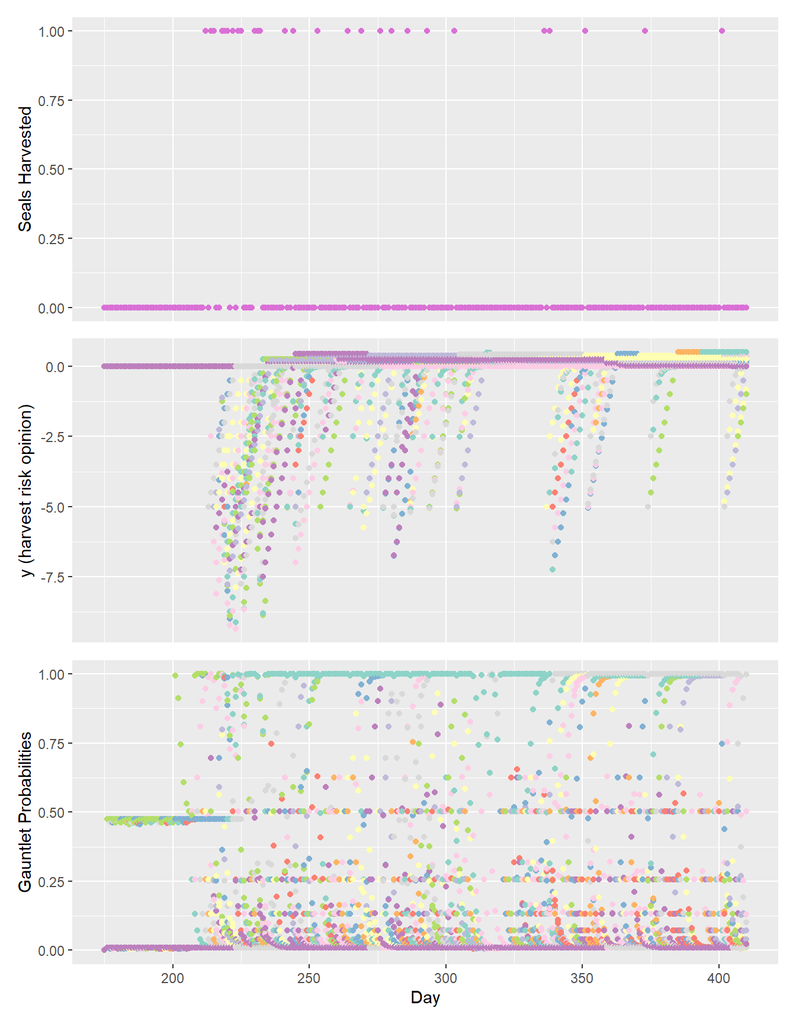

### Salmon Response

The salmon response under this parameterization is as follows:

|  | Chum | Chinook_GR | Chinook_LN |
| --- | --- | --- | --- |
| Escape | 8873 | 12493 | 497 |
| Catch | 6227 | 4956 | 83 |
| Predated | 10573 | 2360 | 220 |

### Parameter Table

|  | Value |
| --- | --- |
| num_seals | 150.00 |
| num_zc | 80.00 |
| num_ej | 10.00 |
| zone_efficiency | 0.25 |
| zone_steepness | 10.00 |
| chum_residence | 21.00 |
| gr_residence | 14.00 |
| locnis_residence | 7.00 |